# MSc Statistical Rob correction -Jan29

# Housekeeping

### Preamble

By Katherine Duchesneau

We are working with the roots Lesion and Mycorrhiza dataset for now.

### R details

This section contains all the necessary details about the R version and package version used to run this Notebook.

- File creation date: 2018-02-09
- R version 3.4.1 (2017-06-30)
- `tidyverse` package version: 1.2.1
- `lme4` package version 1.1.13
- `MASS` package version 7.3.47
- `MuMIn` package version 1.15.6
- `emmeans` package version 0.9.1
- `boot` package version 1.3.20
- `brms` package version 2.0.1
- `loo` package version 1.1.0
- `fitdistrplus` package version 1.0.9
- `mefa` package version 3.2.7
- `library(devtools)` and `install_github("vqv/ggbiplot")` package version 0.55
- also requires [rtools](https://cran.r-project.org/bin/windows/Rtools/)

### Load Packages and Functions

Load a custome theme for clean, readable graphs:

Overdispersion function, tests for overdispersion in GLMM:

# Introducing the Data

### Load/ Modify data: Co-occurence

[output not shown]

### Load/ Modify data: Totals

### Field survey data

```r
Soil_characteristics <- read.csv("CSV/Soil_characteristics.csv", sep="\t")
```

[output not shown]

### Variable descriptions

The variables are:

Co-occurence:

- **indiv2:** The unique code given to a sample. In this dataset the unique sample code repeats 100 times for each cross where an observation was taken on the root sample.
- **None.Path:** A binary representation of whether a sign of pathogen activity was recorded (0) or not (1).
- **Lesion:** The counterpart to the previous variable (None.Path). A binary representation of whether a sign of pathogen activity was recorded (1) or not (0).
- **None.Myc:** A binary representation of whether a sign of myccorhizal activity was recorded (0) or not (1).
- **Mycorrhiza:** The counterpart to the previous variable (None.Myc). A binary representation of whether a sign of mycorrhizal activity was recorded (1) or not (0).
- **None.Herb:** A binary representation of whether herbivory was recorded (0) or not (1).
- **Herbivory:** The counterpart to the previous variable (None.Herb). A binary representation of whether Herbivoryn was recorded (1) or not (0).
- **Population (pop):** The coding number representing the population at which the sample was collected.
- **location:** A code representing the whether the sample was collected inside a Alliaria petiolata population (I) or whther it was collected at least 7 m outside of he furthest individual in the A. petiolata population (O).
- **species:** The particular species to which the sample belongs.
- **Cross:** The particular cross number where the data was recorded on the individual sample.

Total scores:

- **indiv:** The unique code given to a sample.
- **Decay:** The total number of crosses where decay was recorded an individual sample when doing a total of 100 crosses/ sample.
- **Pathogen:** The total number of crosses where pathogen was recorded on an individual sample when doing a total of 100 crosses/ sample.
- **Hyphae:** The total number of crosses where non-myccorhizal hyphae was recorded on an individual sample when doing a total of 100 crosses/ sample.
- **None.Path:** The total number of crosses where no signs of pathogen activities were recorded on an individual sample when doing a total of 100 crosses/ sample. Note that the total of Decay, Pathogen, Hyphae, and None.Path must come to 100 per individual to account for all 100 crosses.
- **Arbuscule:** The total number of crosses where an arbuscule was recorded on an individual sample when doing a total of 100 crosses/ sample.
- **Vesicules:** The total number of crosses where a vesicule was recorded on an individual sample when doing a total of 100 crosses/ sample.
- **M_Hyphae:** The total number of crosses where myccorhizal hyphae was recorded on an individual sample when doing a total of 100 crosses/ sample.
- **None.Myc:** The total number of crosses where no signs of mycorrhizal activities were recorded on an individual sample when doing a total of 100 crosses/ sample. Note that the total of Arbuscules, Vesicules, M_Hyphae, and None.Myc must come to 100 per individual to account for all 100 crosses.
- **Herbivory:** The total number of crosses where herbivory was recorded on an individual sample when doing a total of 100 crosses/ sample.
- **None.Herb:** The total number of crosses where no signs of herbivory was recorded on an individual sample when doing a total of 100 crosses/ sample. Note that the total of Herbivory, and None.Herb must come to 100 per individual to account for all 100 crosses.
- **Population (pop):** The coding number representing the population at which the sample was collected.
- **location:** A code representing the whether the sample was collected inside a Alliaria petiolata population (I) or whther it was collected at least 7 m outside of he furthest individual in the A. petiolata population (O).
- **species:** The particular species to which the sample belongs.

# Reviewing of hypotheses:

## Question 1: Is there evidence that Mycorrhizal colonization provides protection against root pathogen damage?

## Question 2: Do these effects vary among species?

### Hypothesis 1

Mycorrhizal colonization protects roots from lesions and herbivory.

### Hypothesis 2

A. petiolata invasion reduces mycorrhizal colonization and increases pathogen colonization and herbivory

### Hypothesis 3

Cycorrhizal colonization is reduced in the presence of A. petiolata

### Hypothesis 4

Mycorrhizal protection is completely lost in the presence of A. petiolata

## Molecular data Hypothesis

### Hypothesis 1

A. petiolata invasion changes the diversity of mycorrhizal and other fungal species present in the soil.

I will find that the molecular data from the soil extraction supports this claim by having a reduced biodiversity and abundance of mycorrhiza in samples taken inside A. petiolata populations.

### Hypothesis 2

There will be a negative correlation between mycorrhizal and fungal pathogen diversity.

# Field Data Analysis

## Plant length and GM presence

```r
confint(mod1)
```

```
Computing profile confidence intervals ...
```

```
                                               2.5 %     97.5 %
.sig01                                    0.01963921 0.16258131
.sigma                                    0.28096327 0.33850558
(Intercept)                               2.19817644 2.48515490
Locationout                              -0.22469501 0.14891543
SpeciesAnemone_hepatica                  -0.01319870 0.47949790
SpeciesCircaea_lutetiana                  0.87828687 1.29033635
SpeciesGallium_aparine                    1.26920608 1.65925061
SpeciesGeranium_robertinum                0.59591108 1.00763645
SpeciesMaianthemum_racemosum              0.31810708 0.78817334
SpeciesSolidago_canadensis                1.44974225 1.82335269
Locationout:SpeciesAnemone_hepatica      -0.11265649 0.54145529
Locationout:SpeciesCircaea_lutetiana     -0.52495034 0.04066983
Locationout:SpeciesGallium_aparine       -0.47948584 0.07045383
Locationout:SpeciesGeranium_robertinum   -0.20959317 0.35592002
Locationout:SpeciesMaianthemum_racemosum -0.19718336 0.44252670
Locationout:SpeciesSolidago_canadensis   -0.38023461 0.14813034
```

## Floristic composition and GM presence

### Linear discriminate analysis

```r
table(FloristicSurvey$GM_Coverage_category)
```

```
     None   Med_Low  Med_High Overtaken
       82        24        58        34
```

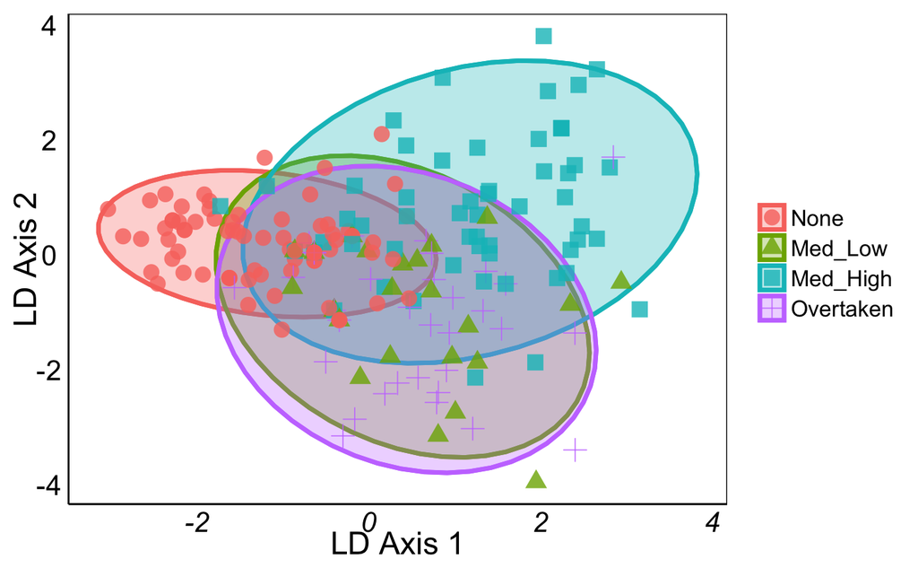

### Cluster analysis

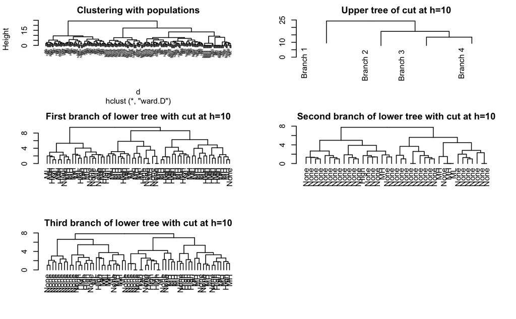

### NMDS

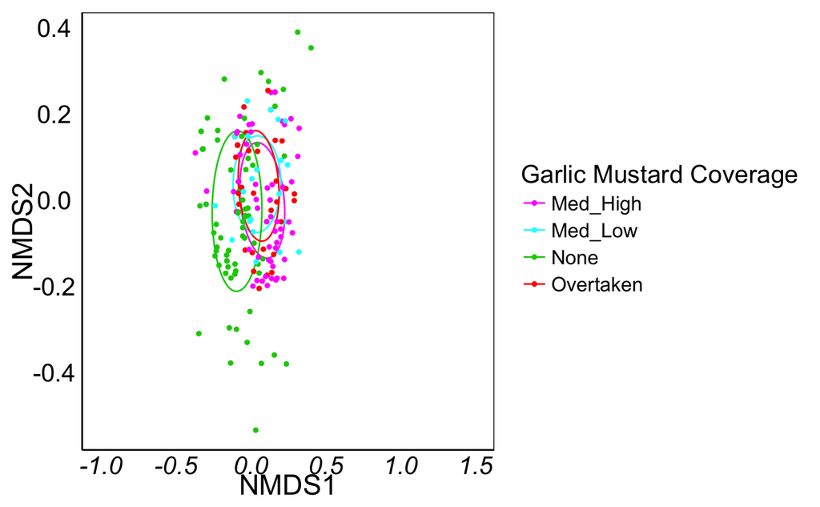

### PCA

```r
FloristicSurvey<-FloristicSurvey[,-56]
FloristicSurvey.pca <- prcomp(FloristicSurvey[,4:(ncol(FloristicSurvey))],center = TRUE)
summary(FloristicSurvey.pca)
fviz_eig(FloristicSurvey.pca,addlabels=TRUE,hjust = -0.3)+theme_simple()

round(FloristicSurvey.pca$sdev^2/sum(FloristicSurvey.pca$sdev^2)*100,2)
# About 25% explained by my first 2 eigenvectors. 50% by the first 6.
```

### Modeling (redundancy analysis)

species comp ~ GMcov * pop + soil characteristics inside and outside as covariates?

```r
anova.cca(formulaRDA,by="axis", step=1000)
```

```
Permutation test for rda under reduced model
Marginal tests for axes
Permutation: free
Number of permutations: 999

Model: rda(formula = sp.comp ~ GM_Coverage, data = var)
          Df Variance      F Pr(>F)
RDA1       1  0.14507 9.9366  0.001 ***
Residual 196  2.86149
---
Signif. codes:  0 ‘***’ 0.001 ‘**’ 0.01 ‘*’ 0.05 ‘.’ 0.1 ‘ ’ 1
```

*Note that I redid this with GM_coverage_catogory and i didnt find ANY significance!